# Data Analysis on *"Alpha Awari"*

### Master Thesis

##### Davide *Mariotti *- *2640152***

# Why this data

Using the best neural network player that our Alpha Awari was able to produce, three datasets have been created in order to better analyze the strenght and understand how many times the network is able to choose the correct move. In this work an analysis on the three datasets is provided.

The three datasets are:

- Matches dataset, dataset that describe how many optimal and suboptimal moves the network can choose on each match.
- Moves dataset, dataset that describe in deep the moves of our work.
- Opponent dataset, summarize the number of wins or lose for each different opponent.

# Dataset Description

## Matches dataset

In the following table the meaning of each column is explained:

| **Column Name** | **Column Description** |
| --- | --- |
| Match | Progressive number of matches. |
| Optimal_moves | Number of optimal moves selected in the match. |
| Sub_optimal_moves | Number of sub-optimal moves selected in the match. |
| Win | 1 if the neural network win the match 0 otherwise. |
| Number_of_turns | Total number of turns in the match. |

## Moves dataset

In the following table the meaning of each column is explained:

| **Column Name** | **Column Description** |
| --- | --- |
| Board | Represent the number of seeds of each pit. |
| best_move_selected | 1 when the best move is selected 0 otherwise. |
| Loss | Points lost with this move. |
| Move_selected | Move selected from the neural network. |
| p-value | Policy values based on the neural network evaluation. |

## Opponent dataset

In the following table the meaning of each column is explained:

| **Column Name** | **Column Description** |
| --- | --- |
| Opponent | Name of the opponent. |
| Win_p1 | Number of wins when the neural network plays first. |
| Lost_p1 | Number of match lose when the neural network plays first. |
| Draw_p1 | Number of match draw when the neural network plays first. |
| Win_p2 | Number of wins when the neural network plays second. |
| Lost_p2 | Number of match lose when the neural network plays second. |
| Draw_p2 | Number of match draw when the neural network plays second. |
| Optimal_moves_nn | Number of optmial moves selected with the opponent. |
| Sub_optimal_moves_nn | Number of sub-optmial moves selected with the opponent. |

```python
import pandas as pd
import math
import matplotlib.pyplot as plt



moves_data = pd.read_csv('moves.csv', sep=',')

# Display the dataset

pd.set_option('display.max_rows', 200)
moves_data
```

|  | Board | Move_selected | best_move_selected | p-value | Loss |
| --- | --- | --- | --- | --- | --- |
| 0 | ['4', '4', '4', '4', '4', '4', '4', '4', '4', ... | 5 | 1 | [0.0, 0.0, 0.0, 0.0, 0.0, 1.0, 0.0] | 0 |
| 1 | ['5', '5', '5', '5', '4', '0', '5', '5', '5', ... | 4 | 1 | [0.0, 0.0, 0.061224489795918366, 0.0, 0.938775... | 0 |
| 2 | ['6', '6', '6', '5', '0', '1', '6', '6', '6', ... | 5 | 0 | [0.02040816326530612, 0.0, 0.3877551020408163,... | 2 |
| 3 | ['7', '7', '6', '5', '0', '0', '7', '0', '7', ... | 2 | 0 | [0.0, 0.04081632653061224, 0.9387755102040817,... | 2 |
| 4 | ['8', '8', '1', '7', '0', '1', '8', '1', '0', ... | 2 | 0 | [0.14285714285714285, 0.02040816326530612, 0.3... | 6 |
| 5 | ['9', '8', '0', '8', '0', '1', '8', '1', '0', ... | 5 | 1 | [0.24489795918367346, 0.32653061224489793, 0.0... | 0 |
| 6 | ['9', '8', '0', '8', '0', '0', '9', '0', '1', ... | 1 | 1 | [0.16326530612244897, 0.6122448979591837, 0.0,... | 0 |
| 7 | ['10', '1', '2', '10', '0', '0', '10', '1', '2... | 2 | 1 | [0.24489795918367346, 0.32653061224489793, 0.4... | 0 |
| 8 | ['11', '2', '1', '12', '0', '0', '10', '1', '2... | 2 | 0 | [0.12244897959183673, 0.3469387755102041, 0.48... | 2 |
| 9 | ['11', '2', '0', '13', '0', '0', '10', '1', '0... | 1 | 0 | [0.14285714285714285, 0.8367346938775511, 0.0,... | 4 |
| 10 | ['11', '0', '1', '14', '0', '0', '10', '1', '0... | 2 | 1 | [0.20408163265306123, 0.0, 0.6326530612244898,... | 0 |
| 11 | ['11', '0', '0', '15', '0', '0', '10', '0', '1... | 0 | 1 | [0.5918367346938775, 0.0, 0.0, 0.4081632653061... | 0 |
| 12 | ['1', '0', '0', '16', '1', '1', '11', '1', '2'... | 5 | 1 | [0.12244897959183673, 0.0, 0.0, 0.040816326530... | 0 |
| 13 | ['2', '1', '1', '17', '2', '1', '0', '3', '3',... | 3 | 1 | [0.061224489795918366, 0.12244897959183673, 0.... | 0 |
| 14 | ['4', '0', '2', '0', '4', '3', '2', '5', '0', ... | 2 | 1 | [0.2857142857142857, 0.0, 0.5918367346938775, ... | 0 |
| 15 | ['5', '0', '0', '1', '5', '3', '2', '0', '1', ... | 5 | 1 | [0.12244897959183673, 0.0, 0.0, 0.081632653061... | 0 |
| 16 | ['6', '1', '1', '0', '5', '0', '3', '1', '0', ... | 2 | 0 | [0.20408163265306123, 0.04081632653061224, 0.7... | 2 |
| 17 | ['6', '1', '0', '1', '5', '0', '3', '0', '1', ... | 0 | 0 | [0.5102040816326531, 0.08163265306122448, 0.0,... | 6 |
| 18 | ['4', '4', '4', '4', '4', '4', '4', '4', '4', ... | 5 | 1 | [0.0, 0.0, 0.0, 0.0, 0.0, 1.0, 0.0] | 0 |
| 19 | ['5', '5', '5', '5', '4', '0', '5', '5', '5', ... | 4 | 1 | [0.0, 0.0, 0.061224489795918366, 0.0, 0.938775... | 0 |
| 20 | ['6', '6', '6', '5', '0', '1', '6', '6', '6', ... | 5 | 0 | [0.04081632653061224, 0.02040816326530612, 0.2... | 4 |
| 21 | ['7', '7', '6', '5', '0', '0', '7', '0', '7', ... | 2 | 1 | [0.16326530612244897, 0.02040816326530612, 0.7... | 0 |
| 22 | ['8', '8', '1', '7', '0', '1', '8', '1', '8', ... | 2 | 1 | [0.02040816326530612, 0.04081632653061224, 0.5... | 0 |
| 23 | ['8', '8', '0', '8', '0', '1', '8', '1', '8', ... | 1 | 1 | [0.16326530612244897, 0.46938775510204084, 0.0... | 0 |
| 24 | ['9', '1', '2', '10', '0', '0', '9', '2', '0',... | 0 | 1 | [0.7346938775510204, 0.10204081632653061, 0.14... | 0 |
| 25 | ['1', '3', '4', '12', '1', '1', '10', '3', '1'... | 4 | 0 | [0.20408163265306123, 0.04081632653061224, 0.0... | 3 |
| 26 | ['1', '3', '4', '12', '0', '2', '10', '3', '0'... | 0 | 1 | [0.4489795918367347, 0.061224489795918366, 0.4... | 0 |
| 27 | ['1', '4', '4', '12', '0', '2', '10', '3', '0'... | 0 | 1 | [0.8163265306122449, 0.02040816326530612, 0.08... | 0 |
| 28 | ['0', '5', '4', '12', '0', '2', '10', '3', '0'... | 2 | 1 | [0.0, 0.20408163265306123, 0.5918367346938775,... | 0 |
| 29 | ['0', '5', '0', '13', '1', '3', '11', '0', '1'... | 4 | 1 | [0.0, 0.02040816326530612, 0.0, 0.0, 0.6734693... | 0 |

[output cut: 171 more lines]

37336 rows × 5 columns

```python
matches_data = pd.read_csv('Matches.csv', sep=',')

# Display the dataset
pd.set_option('display.max_rows', 200)
matches_data
```

|  | Match | Optimal_moves | Sub_optimal_moves | win | Number_turns |
| --- | --- | --- | --- | --- | --- |
| 0 | Game0 | 11 | 7 | 0 | 36 |
| 1 | Game1 | 29 | 6 | 0 | 70 |
| 2 | Game2 | 9 | 8 | 0 | 34 |
| 3 | Game3 | 17 | 11 | 0 | 56 |
| 4 | Game4 | 20 | 11 | 0 | 62 |
| 5 | Game5 | 16 | 11 | 0 | 54 |
| 6 | Game6 | 15 | 11 | 0 | 52 |
| 7 | Game7 | 30 | 15 | 0 | 90 |
| 8 | Game8 | 27 | 16 | 0 | 86 |
| 9 | Game9 | 19 | 9 | 0 | 56 |
| 10 | Game10 | 41 | 8 | 0 | 98 |
| 11 | Game11 | 59 | 7 | 0 | 132 |
| 12 | Game12 | 19 | 9 | 0 | 56 |
| 13 | Game13 | 37 | 11 | 0 | 96 |
| 14 | Game14 | 23 | 10 | 0 | 66 |
| 15 | Game15 | 23 | 11 | 0 | 68 |
| 16 | Game16 | 20 | 13 | 0 | 66 |
| 17 | Game17 | 15 | 13 | 0 | 56 |
| 18 | Game18 | 13 | 7 | 0 | 40 |
| 19 | Game19 | 33 | 11 | 0 | 88 |
| 20 | Game20 | 12 | 12 | 0 | 48 |
| 21 | Game21 | 30 | 11 | 0 | 82 |
| 22 | Game22 | 16 | 8 | 0 | 48 |
| 23 | Game23 | 26 | 10 | 0 | 72 |
| 24 | Game24 | 36 | 6 | 0 | 84 |
| 25 | Game25 | 16 | 7 | 0 | 46 |
| 26 | Game26 | 20 | 9 | 0 | 58 |
| 27 | Game27 | 17 | 12 | 0 | 58 |
| 28 | Game28 | 30 | 10 | 0 | 80 |
| 29 | Game29 | 11 | 10 | 0 | 42 |

[output cut: 171 more lines]

900 rows × 5 columns

```python
opponent_data = pd.read_csv('opponent.csv', sep=',')

# Display the dataset
opponent_data
```

|  | Opponent | Win_p1 | Lost_p1 | Draw_p1 | Win_p2 | Lost_p2 | Draw_p2 | Optimal_moves_nn | Sub_optimal_moves_nn |
| --- | --- | --- | --- | --- | --- | --- | --- | --- | --- |
| 0 | fop05 | 0 | 50 | 0 | 1 | 49 | 0 | 2272 | 944 |
| 1 | fop1 | 3 | 47 | 0 | 0 | 50 | 0 | 2530 | 997 |
| 2 | fop2 | 6 | 41 | 3 | 7 | 43 | 0 | 2994 | 1039 |
| 3 | fop3 | 7 | 42 | 1 | 11 | 36 | 3 | 3415 | 1195 |
| 4 | fop4 | 24 | 25 | 1 | 25 | 21 | 4 | 3825 | 1232 |
| 5 | fop5 | 28 | 19 | 3 | 39 | 10 | 1 | 4191 | 1545 |
| 6 | fop8 | 44 | 6 | 0 | 48 | 1 | 1 | 3634 | 1663 |
| 7 | oracle | 0 | 50 | 0 | 0 | 50 | 0 | 1882 | 883 |
| 8 | random | 50 | 0 | 0 | 50 | 0 | 0 | 1818 | 1277 |

# How many positions have been Analyzed?

Count how many board positions have been analyzed from the neural network

```python
#count how many board positions have been analyzed from the nn
value_counts=moves_data['Board'].value_counts()
value_counts
```

```
['4', '4', '4', '4', '4', '4', '4', '4', '4', '4', '4', '4']       450
['5', '5', '5', '5', '4', '4', '4', '4', '4', '4', '4', '0']       291
['5', '5', '5', '5', '4', '0', '5', '5', '5', '5', '4', '0']       147
['5', '4', '4', '4', '4', '0', '5', '0', '6', '6', '5', '5']       137
['5', '4', '4', '4', '4', '4', '4', '4', '0', '5', '5', '5']       131
['6', '6', '6', '5', '4', '0', '5', '5', '5', '5', '0', '1']       111
['5', '5', '5', '4', '4', '0', '5', '5', '5', '5', '0', '5']       111
['1', '1', '0', '0', '1', '1', '0', '0', '0', '1', '0', '0']        99
['1', '1', '0', '1', '0', '1', '0', '0', '1', '0', '0', '0']        99
['1', '0', '1', '0', '1', '1', '0', '0', '0', '0', '1', '0']        99
['1', '1', '1', '1', '1', '0', '0', '1', '0', '0', '0', '0']        87
['1', '1', '1', '1', '1', '1', '0', '0', '0', '0', '0', '0']        87
['1', '1', '0', '1', '1', '1', '0', '0', '0', '0', '0', '0']        86
['1', '1', '0', '1', '1', '0', '0', '1', '0', '0', '0', '0']        86
['1', '1', '1', '1', '0', '1', '0', '0', '1', '0', '0', '0']        85
['0', '1', '1', '0', '1', '1', '0', '0', '0', '0', '0', '1']        84
['1', '1', '1', '0', '1', '1', '0', '0', '0', '1', '0', '0']        83
['1', '1', '0', '1', '1', '1', '0', '0', '0', '0', '1', '0']        83
['1', '0', '1', '1', '1', '1', '0', '0', '0', '0', '0', '1']        80
['6', '6', '0', '5', '5', '1', '6', '0', '6', '6', '1', '6']        74
['6', '4', '4', '4', '4', '0', '5', '0', '2', '7', '6', '6']        65
['6', '6', '6', '5', '4', '0', '5', '5', '5', '0', '5', '1']        65
['1', '1', '0', '1', '0', '1', '0', '0', '0', '1', '0', '0']        64
['1', '1', '0', '0', '1', '1', '0', '0', '0', '0', '1', '0']        63
['1', '1', '1', '0', '1', '1', '0', '0', '0', '0', '0', '0']        62
['1', '0', '1', '0', '1', '1', '0', '0', '0', '0', '0', '1']        62
['1', '1', '1', '0', '0', '1', '0', '0', '1', '0', '0', '0']        59
['1', '1', '1', '0', '1', '0', '0', '1', '0', '0', '0', '0']        59
['5', '4', '4', '4', '4', '0', '0', '6', '2', '7', '6', '6']        58
['6', '5', '5', '5', '4', '0', '5', '0', '6', '6', '5', '1']        57
['7', '7', '1', '6', '5', '1', '6', '6', '0', '6', '1', '2']        55
['6', '6', '6', '5', '0', '1', '6', '6', '6', '5', '0', '1']        53
['7', '6', '0', '6', '5', '1', '6', '6', '6', '5', '0', '0']        48
['6', '5', '5', '5', '0', '1', '6', '1', '7', '6', '0', '6']        46
['6', '5', '5', '5', '0', '1', '6', '1', '0', '7', '6', '6']        45
['6', '6', '5', '5', '4', '0', '5', '5', '0', '6', '5', '1']        45
['8', '7', '1', '7', '0', '2', '7', '7', '0', '7', '1', '1']        44
['6', '5', '5', '5', '0', '1', '6', '0', '8', '6', '5', '1']        43
['7', '7', '1', '5', '5', '0', '7', '0', '0', '7', '2', '7']        42
['7', '7', '0', '7', '5', '1', '6', '6', '0', '6', '0', '3']        42
```

[output cut: 147 more lines]

```
['0', '6', '4', '0', '17', '4', '0', '0', '0', '0', '3', '2']        1
['2', '18', '0', '1', '2', '3', '1', '1', '1', '1', '0', '7']        1
['0', '0', '1', '1', '1', '1', '0', '0', '0', '2', '0', '2']         1
['0', '2', '1', '1', '0', '1', '0', '4', '0', '1', '2', '10']        1
['0', '1', '1', '0', '1', '0', '0', '1', '2', '2', '0', '1']         1
['0', '0', '2', '1', '0', '13', '0', '1', '2', '1', '0', '1']        1
['2', '0', '1', '1', '3', '0', '0', '0', '0', '0', '2', '1']         1
['0', '4', '0', '0', '0', '2', '0', '0', '0', '2', '1', '1']         1
['0', '5', '1', '0', '16', '2', '0', '0', '2', '3', '7', '1']        1
['0', '0', '0', '0', '1', '7', '1', '1', '1', '1', '12', '0']        1
['0', '2', '3', '0', '0', '10', '3', '0', '1', '1', '3', '9']        1
['1', '0', '0', '0', '0', '0', '1', '1', '0', '2', '0', '13']        1
['6', '8', '2', '0', '16', '0', '0', '0', '0', '2', '2', '0']        1
['1', '10', '0', '0', '10', '0', '0', '1', '6', '1', '9', '1']       1
Name: Board, Length: 25064, dtype: int64
```

25064 Different positions analyzed in total.

# How many times the opening moves are evaluated correctly?

Before remove the duplicate is interesting to see how many times the network can select the best initial move.

```python
iniztial_moves_a=moves_data[moves_data.Board == str(['4', '4', '4', '4', '4', '4', '4', '4', '4', '4', '4', '4'])]
iniztial_moves_a
```

|  | Board | Move_selected | best_move_selected | p-value | Loss |
| --- | --- | --- | --- | --- | --- |
| 0 | ['4', '4', '4', '4', '4', '4', '4', '4', '4', ... | 5 | 1 | [0.0, 0.0, 0.0, 0.0, 0.0, 1.0, 0.0] | 0 |
| 18 | ['4', '4', '4', '4', '4', '4', '4', '4', '4', ... | 5 | 1 | [0.0, 0.0, 0.0, 0.0, 0.0, 1.0, 0.0] | 0 |
| 53 | ['4', '4', '4', '4', '4', '4', '4', '4', '4', ... | 5 | 1 | [0.0, 0.0, 0.0, 0.0, 0.0, 1.0, 0.0] | 0 |
| 70 | ['4', '4', '4', '4', '4', '4', '4', '4', '4', ... | 5 | 1 | [0.0, 0.0, 0.0, 0.0, 0.0, 1.0, 0.0] | 0 |
| 98 | ['4', '4', '4', '4', '4', '4', '4', '4', '4', ... | 5 | 1 | [0.0, 0.0, 0.0, 0.0, 0.0, 1.0, 0.0] | 0 |
| 129 | ['4', '4', '4', '4', '4', '4', '4', '4', '4', ... | 5 | 1 | [0.0, 0.0, 0.0, 0.0, 0.0, 1.0, 0.0] | 0 |
| 156 | ['4', '4', '4', '4', '4', '4', '4', '4', '4', ... | 5 | 1 | [0.0, 0.0, 0.0, 0.0, 0.0, 1.0, 0.0] | 0 |
| 182 | ['4', '4', '4', '4', '4', '4', '4', '4', '4', ... | 5 | 1 | [0.0, 0.0, 0.0, 0.0, 0.0, 1.0, 0.0] | 0 |
| 227 | ['4', '4', '4', '4', '4', '4', '4', '4', '4', ... | 5 | 1 | [0.0, 0.0, 0.0, 0.0, 0.0, 1.0, 0.0] | 0 |
| 270 | ['4', '4', '4', '4', '4', '4', '4', '4', '4', ... | 5 | 1 | [0.0, 0.0, 0.0, 0.0, 0.0, 1.0, 0.0] | 0 |
| 298 | ['4', '4', '4', '4', '4', '4', '4', '4', '4', ... | 5 | 1 | [0.0, 0.0, 0.0, 0.0, 0.0, 1.0, 0.0] | 0 |
| 347 | ['4', '4', '4', '4', '4', '4', '4', '4', '4', ... | 5 | 1 | [0.0, 0.0, 0.0, 0.0, 0.0, 1.0, 0.0] | 0 |
| 413 | ['4', '4', '4', '4', '4', '4', '4', '4', '4', ... | 5 | 1 | [0.0, 0.0, 0.0, 0.0, 0.0, 1.0, 0.0] | 0 |
| 441 | ['4', '4', '4', '4', '4', '4', '4', '4', '4', ... | 5 | 1 | [0.0, 0.0, 0.0, 0.0, 0.0, 1.0, 0.0] | 0 |
| 489 | ['4', '4', '4', '4', '4', '4', '4', '4', '4', ... | 5 | 1 | [0.0, 0.0, 0.0, 0.0, 0.0, 1.0, 0.0] | 0 |
| 522 | ['4', '4', '4', '4', '4', '4', '4', '4', '4', ... | 5 | 1 | [0.0, 0.0, 0.0, 0.0, 0.0, 1.0, 0.0] | 0 |
| 556 | ['4', '4', '4', '4', '4', '4', '4', '4', '4', ... | 5 | 1 | [0.0, 0.0, 0.0, 0.0, 0.0, 1.0, 0.0] | 0 |
| 589 | ['4', '4', '4', '4', '4', '4', '4', '4', '4', ... | 5 | 1 | [0.0, 0.0, 0.0, 0.0, 0.0, 1.0, 0.0] | 0 |
| 617 | ['4', '4', '4', '4', '4', '4', '4', '4', '4', ... | 5 | 1 | [0.0, 0.0, 0.0, 0.0, 0.0, 1.0, 0.0] | 0 |
| 637 | ['4', '4', '4', '4', '4', '4', '4', '4', '4', ... | 5 | 1 | [0.0, 0.0, 0.0, 0.0, 0.0, 1.0, 0.0] | 0 |
| 681 | ['4', '4', '4', '4', '4', '4', '4', '4', '4', ... | 5 | 1 | [0.0, 0.0, 0.0, 0.0, 0.0, 1.0, 0.0] | 0 |
| 705 | ['4', '4', '4', '4', '4', '4', '4', '4', '4', ... | 5 | 1 | [0.0, 0.0, 0.0, 0.0, 0.0, 1.0, 0.0] | 0 |
| 746 | ['4', '4', '4', '4', '4', '4', '4', '4', '4', ... | 5 | 1 | [0.0, 0.0, 0.0, 0.0, 0.0, 1.0, 0.0] | 0 |
| 770 | ['4', '4', '4', '4', '4', '4', '4', '4', '4', ... | 5 | 1 | [0.0, 0.0, 0.0, 0.0, 0.0, 1.0, 0.0] | 0 |
| 806 | ['4', '4', '4', '4', '4', '4', '4', '4', '4', ... | 5 | 1 | [0.0, 0.0, 0.0, 0.0, 0.0, 1.0, 0.0] | 0 |
| 848 | ['4', '4', '4', '4', '4', '4', '4', '4', '4', ... | 5 | 1 | [0.0, 0.0, 0.0, 0.0, 0.0, 1.0, 0.0] | 0 |
| 871 | ['4', '4', '4', '4', '4', '4', '4', '4', '4', ... | 5 | 1 | [0.0, 0.0, 0.0, 0.0, 0.0, 1.0, 0.0] | 0 |
| 900 | ['4', '4', '4', '4', '4', '4', '4', '4', '4', ... | 5 | 1 | [0.0, 0.0, 0.0, 0.0, 0.0, 1.0, 0.0] | 0 |
| 929 | ['4', '4', '4', '4', '4', '4', '4', '4', '4', ... | 5 | 1 | [0.0, 0.0, 0.0, 0.0, 0.0, 1.0, 0.0] | 0 |
| 969 | ['4', '4', '4', '4', '4', '4', '4', '4', '4', ... | 5 | 1 | [0.0, 0.0, 0.0, 0.0, 0.0, 1.0, 0.0] | 0 |

[output cut: 171 more lines]

450 rows × 5 columns

```python
iniztial_moves_a=iniztial_moves_a.drop_duplicates()
iniztial_moves_a
```

|  | Board | Move_selected | best_move_selected | p-value | Loss |
| --- | --- | --- | --- | --- | --- |
| 0 | ['4', '4', '4', '4', '4', '4', '4', '4', '4', ... | 5 | 1 | [0.0, 0.0, 0.0, 0.0, 0.0, 1.0, 0.0] | 0 |

All the initial moves when the network is the first player are evaluated at the same way. Choosing the correct move according to the oracle.

```python
iniztial_moves_b=moves_data[moves_data.Board == str(['5', '5', '5', '5', '4', '4', '4', '4', '4', '4', '4', '0'])]
iniztial_moves_b
```

|  | Board | Move_selected | best_move_selected | p-value | Loss |
| --- | --- | --- | --- | --- | --- |
| 1546 | ['5', '5', '5', '5', '4', '4', '4', '4', '4', ... | 5 | 1 | [0.0, 0.0, 0.0, 0.0, 0.0, 1.0, 0.0] | 0 |
| 1566 | ['5', '5', '5', '5', '4', '4', '4', '4', '4', ... | 5 | 1 | [0.0, 0.0, 0.0, 0.0, 0.0, 1.0, 0.0] | 0 |
| 1601 | ['5', '5', '5', '5', '4', '4', '4', '4', '4', ... | 5 | 1 | [0.0, 0.0, 0.0, 0.0, 0.0, 1.0, 0.0] | 0 |
| 1631 | ['5', '5', '5', '5', '4', '4', '4', '4', '4', ... | 5 | 1 | [0.0, 0.0, 0.0, 0.0, 0.0, 1.0, 0.0] | 0 |
| 1648 | ['5', '5', '5', '5', '4', '4', '4', '4', '4', ... | 5 | 1 | [0.0, 0.0, 0.0, 0.0, 0.0, 1.0, 0.0] | 0 |
| 1687 | ['5', '5', '5', '5', '4', '4', '4', '4', '4', ... | 5 | 1 | [0.0, 0.0, 0.0, 0.0, 0.0, 1.0, 0.0] | 0 |
| 1704 | ['5', '5', '5', '5', '4', '4', '4', '4', '4', ... | 5 | 1 | [0.0, 0.0, 0.0, 0.0, 0.0, 1.0, 0.0] | 0 |
| 1730 | ['5', '5', '5', '5', '4', '4', '4', '4', '4', ... | 5 | 1 | [0.0, 0.0, 0.0, 0.0, 0.0, 1.0, 0.0] | 0 |
| 1773 | ['5', '5', '5', '5', '4', '4', '4', '4', '4', ... | 5 | 1 | [0.0, 0.0, 0.0, 0.0, 0.0, 1.0, 0.0] | 0 |
| 1809 | ['5', '5', '5', '5', '4', '4', '4', '4', '4', ... | 5 | 1 | [0.0, 0.0, 0.0, 0.0, 0.0, 1.0, 0.0] | 0 |
| 1845 | ['5', '5', '5', '5', '4', '4', '4', '4', '4', ... | 5 | 1 | [0.0, 0.0, 0.0, 0.0, 0.0, 1.0, 0.0] | 0 |
| 1862 | ['5', '5', '5', '5', '4', '4', '4', '4', '4', ... | 5 | 1 | [0.0, 0.0, 0.0, 0.0, 0.0, 1.0, 0.0] | 0 |
| 1900 | ['5', '5', '5', '5', '4', '4', '4', '4', '4', ... | 5 | 1 | [0.0, 0.0, 0.0, 0.0, 0.0, 1.0, 0.0] | 0 |
| 1931 | ['5', '5', '5', '5', '4', '4', '4', '4', '4', ... | 5 | 1 | [0.0, 0.0, 0.0, 0.0, 0.0, 1.0, 0.0] | 0 |
| 1954 | ['5', '5', '5', '5', '4', '4', '4', '4', '4', ... | 5 | 1 | [0.0, 0.0, 0.0, 0.0, 0.0, 1.0, 0.0] | 0 |
| 1971 | ['5', '5', '5', '5', '4', '4', '4', '4', '4', ... | 5 | 1 | [0.0, 0.0, 0.0, 0.0, 0.0, 1.0, 0.0] | 0 |
| 2003 | ['5', '5', '5', '5', '4', '4', '4', '4', '4', ... | 5 | 1 | [0.0, 0.0, 0.0, 0.0, 0.0, 1.0, 0.0] | 0 |
| 2020 | ['5', '5', '5', '5', '4', '4', '4', '4', '4', ... | 5 | 1 | [0.0, 0.0, 0.0, 0.0, 0.0, 1.0, 0.0] | 0 |
| 2063 | ['5', '5', '5', '5', '4', '4', '4', '4', '4', ... | 5 | 1 | [0.0, 0.0, 0.0, 0.0, 0.0, 1.0, 0.0] | 0 |
| 2118 | ['5', '5', '5', '5', '4', '4', '4', '4', '4', ... | 5 | 1 | [0.0, 0.0, 0.0, 0.0, 0.0, 1.0, 0.0] | 0 |
| 2150 | ['5', '5', '5', '5', '4', '4', '4', '4', '4', ... | 5 | 1 | [0.0, 0.0, 0.0, 0.0, 0.0, 1.0, 0.0] | 0 |
| 2192 | ['5', '5', '5', '5', '4', '4', '4', '4', '4', ... | 5 | 1 | [0.0, 0.0, 0.0, 0.0, 0.0, 1.0, 0.0] | 0 |
| 2228 | ['5', '5', '5', '5', '4', '4', '4', '4', '4', ... | 5 | 1 | [0.0, 0.0, 0.0, 0.0, 0.0, 1.0, 0.0] | 0 |
| 2251 | ['5', '5', '5', '5', '4', '4', '4', '4', '4', ... | 5 | 1 | [0.0, 0.0, 0.0, 0.0, 0.0, 1.0, 0.0] | 0 |
| 2275 | ['5', '5', '5', '5', '4', '4', '4', '4', '4', ... | 5 | 1 | [0.0, 0.0, 0.0, 0.0, 0.0, 1.0, 0.0] | 0 |
| 2301 | ['5', '5', '5', '5', '4', '4', '4', '4', '4', ... | 5 | 1 | [0.0, 0.0, 0.0, 0.0, 0.0, 1.0, 0.0] | 0 |
| 2318 | ['5', '5', '5', '5', '4', '4', '4', '4', '4', ... | 5 | 1 | [0.0, 0.0, 0.0, 0.0, 0.0, 1.0, 0.0] | 0 |
| 2355 | ['5', '5', '5', '5', '4', '4', '4', '4', '4', ... | 5 | 1 | [0.0, 0.0, 0.0, 0.0, 0.0, 1.0, 0.0] | 0 |
| 2382 | ['5', '5', '5', '5', '4', '4', '4', '4', '4', ... | 5 | 1 | [0.0, 0.0, 0.0, 0.0, 0.0, 1.0, 0.0] | 0 |
| 2432 | ['5', '5', '5', '5', '4', '4', '4', '4', '4', ... | 5 | 1 | [0.0, 0.0, 0.0, 0.0, 0.0, 1.0, 0.0] | 0 |

[output cut: 171 more lines]

291 rows × 5 columns

```python
iniztial_moves_b=iniztial_moves_a.drop_duplicates()
iniztial_moves_b
```

|  | Board | Move_selected | best_move_selected | p-value | Loss |
| --- | --- | --- | --- | --- | --- |
| 0 | ['4', '4', '4', '4', '4', '4', '4', '4', '4', ... | 5 | 1 | [0.0, 0.0, 0.0, 0.0, 0.0, 1.0, 0.0] | 0 |

# Remove Duplicates

Cleaning the moves-dataset from the board positions repeated. We define a board position repeated when policy vector, move chosen and board are exactly the same.

```python
moves_data = moves_data.drop_duplicates()
```

Analyze the moves repeated more than one time, but evaluated in different ways.

```python
value_counts=moves_data['Board'].value_counts()
value_counts=value_counts[value_counts > 1]
value_counts
```

```
['1', '1', '0', '1', '0', '1', '0', '0', '0', '1', '0', '0']      16
['1', '0', '1', '0', '1', '1', '0', '0', '0', '0', '1', '0']      13
['1', '1', '0', '0', '1', '1', '0', '0', '0', '0', '1', '0']      13
['1', '1', '0', '1', '0', '1', '0', '0', '1', '0', '0', '0']      12
['1', '1', '0', '1', '1', '1', '0', '0', '0', '0', '1', '0']      10
['1', '1', '0', '0', '1', '1', '0', '0', '0', '1', '0', '0']      10
['1', '1', '1', '0', '1', '0', '0', '1', '0', '0', '0', '0']      10
['1', '1', '1', '0', '0', '1', '0', '0', '1', '0', '0', '0']       8
['1', '1', '1', '2', '0', '1', '0', '0', '1', '0', '0', '0']       8
['0', '1', '1', '0', '1', '1', '0', '0', '0', '0', '0', '1']       7
['1', '1', '1', '1', '0', '1', '0', '0', '1', '0', '0', '0']       7
['1', '1', '0', '1', '1', '0', '0', '0', '0', '1', '0', '0']       6
['1', '1', '1', '0', '1', '1', '0', '0', '1', '0', '0', '0']       6
['1', '1', '1', '1', '2', '1', '0', '0', '0', '0', '0', '0']       6
['1', '1', '0', '1', '1', '1', '0', '0', '0', '1', '0', '0']       6
['1', '1', '1', '0', '1', '0', '0', '0', '1', '0', '0', '0']       6
['1', '1', '0', '1', '1', '0', '0', '1', '0', '0', '0', '0']       6
['1', '1', '1', '0', '2', '1', '0', '0', '0', '0', '0', '0']       6
['1', '0', '1', '0', '1', '1', '0', '0', '0', '1', '0', '0']       6
['1', '1', '1', '1', '0', '0', '0', '1', '0', '0', '0', '0']       5
['1', '1', '1', '1', '1', '0', '0', '2', '0', '0', '0', '0']       5
['1', '1', '1', '1', '0', '1', '0', '0', '1', '1', '0', '0']       5
['1', '1', '1', '0', '1', '2', '0', '0', '0', '1', '0', '0']       5
['1', '1', '1', '1', '0', '3', '0', '1', '0', '0', '0', '0']       5
['1', '0', '1', '1', '0', '1', '0', '0', '1', '0', '0', '0']       5
['1', '1', '0', '1', '0', '1', '0', '1', '0', '1', '1', '0']       5
['1', '1', '1', '1', '3', '1', '0', '0', '0', '0', '0', '0']       5
['1', '1', '1', '0', '3', '1', '0', '0', '0', '0', '0', '0']       5
['1', '1', '1', '1', '2', '2', '0', '0', '0', '0', '0', '0']       5
['0', '1', '0', '1', '1', '1', '0', '0', '0', '0', '0', '1']       5
['0', '1', '1', '0', '1', '1', '0', '1', '0', '0', '0', '2']       4
['1', '0', '0', '1', '1', '1', '0', '0', '0', '0', '1', '0']       4
['1', '2', '0', '0', '1', '0', '0', '0', '1', '0', '0', '0']       4
['1', '0', '1', '0', '1', '0', '0', '0', '0', '0', '1', '0']       4
['1', '2', '0', '1', '1', '1', '0', '0', '0', '0', '1', '0']       4
['1', '1', '0', '1', '0', '0', '0', '1', '0', '0', '0', '0']       4
['1', '0', '1', '1', '1', '0', '0', '1', '0', '0', '0', '0']       4
['1', '1', '1', '1', '0', '1', '0', '1', '0', '0', '0', '0']       4
['1', '1', '0', '1', '2', '1', '0', '0', '0', '0', '0', '0']       4
['0', '0', '0', '1', '1', '2', '0', '0', '0', '0', '1', '2']       4
```

[output cut: 147 more lines]

```
['0', '1', '1', '0', '21', '0', '0', '0', '0', '1', '0', '0']      2
['0', '0', '1', '0', '1', '2', '0', '0', '1', '0', '1', '3']       2
['1', '1', '1', '1', '0', '0', '1', '2', '1', '0', '0', '0']       2
['0', '1', '1', '0', '0', '0', '0', '1', '1', '0', '1', '15']      2
['1', '1', '2', '1', '2', '1', '0', '0', '0', '0', '0', '0']       2
['1', '1', '0', '2', '0', '0', '0', '1', '0', '0', '0', '0']       2
['0', '0', '0', '2', '1', '3', '0', '0', '0', '0', '1', '3']       2
['0', '0', '0', '1', '1', '2', '0', '0', '0', '2', '0', '16']      2
['1', '1', '1', '2', '2', '1', '0', '0', '0', '0', '0', '0']       2
['0', '0', '0', '0', '4', '1', '0', '0', '0', '0', '0', '4']       2
['1', '1', '1', '1', '0', '1', '0', '2', '1', '0', '1', '0']       2
['1', '2', '3', '0', '2', '1', '0', '0', '0', '0', '0', '0']       2
['0', '0', '0', '0', '1', '3', '0', '0', '0', '0', '0', '5']       2
['1', '1', '1', '2', '3', '2', '0', '0', '0', '0', '0', '2']       2
Name: Board, Length: 372, dtype: int64
```

```python
len(value_counts[value_counts > 1])
```

```
372
```

We have 372 moves evaluated at least 2 times by the neural network in different ways.

As we can see from the cells below most of the time just the policy network is slightly different. But there are also some occurencies where the neural network chosen a different move, passing from an optimal move to a suboptimal one.

```python
moves_data[moves_data.Board == str(['1', '1', '0', '1', '0', '1', '0', '0', '0', '1', '0', '0'])]
```

|  | Board | Move_selected | best_move_selected | p-value | Loss |
| --- | --- | --- | --- | --- | --- |
| 5908 | ['1', '1', '0', '1', '0', '1', '0', '0', '0', ... | 3 | 1 | [0.04081632653061224, 0.1836734693877551, 0.0,... | 0 |
| 5938 | ['1', '1', '0', '1', '0', '1', '0', '0', '0', ... | 3 | 1 | [0.04081632653061224, 0.24489795918367346, 0.0... | 0 |
| 5944 | ['1', '1', '0', '1', '0', '1', '0', '0', '0', ... | 3 | 1 | [0.10204081632653061, 0.30612244897959184, 0.0... | 0 |
| 8592 | ['1', '1', '0', '1', '0', '1', '0', '0', '0', ... | 3 | 1 | [0.04081632653061224, 0.2857142857142857, 0.0,... | 0 |
| 8598 | ['1', '1', '0', '1', '0', '1', '0', '0', '0', ... | 3 | 1 | [0.16326530612244897, 0.30612244897959184, 0.0... | 0 |
| 12994 | ['1', '1', '0', '1', '0', '1', '0', '0', '0', ... | 3 | 1 | [0.0, 0.30612244897959184, 0.0, 0.693877551020... | 0 |
| 13018 | ['1', '1', '0', '1', '0', '1', '0', '0', '0', ... | 3 | 1 | [0.0, 0.2653061224489796, 0.0, 0.7346938775510... | 0 |
| 13024 | ['1', '1', '0', '1', '0', '1', '0', '0', '0', ... | 3 | 1 | [0.0, 0.14285714285714285, 0.0, 0.857142857142... | 0 |
| 13030 | ['1', '1', '0', '1', '0', '1', '0', '0', '0', ... | 3 | 1 | [0.14285714285714285, 0.2653061224489796, 0.0,... | 0 |
| 13139 | ['1', '1', '0', '1', '0', '1', '0', '0', '0', ... | 3 | 1 | [0.0, 0.0, 0.0, 1.0, 0.0, 0.0, 0.0] | 0 |
| 13479 | ['1', '1', '0', '1', '0', '1', '0', '0', '0', ... | 3 | 1 | [0.0, 0.24489795918367346, 0.0, 0.755102040816... | 0 |
| 13503 | ['1', '1', '0', '1', '0', '1', '0', '0', '0', ... | 3 | 1 | [0.0, 0.16326530612244897, 0.0, 0.836734693877... | 0 |
| 13509 | ['1', '1', '0', '1', '0', '1', '0', '0', '0', ... | 3 | 1 | [0.0, 0.12244897959183673, 0.0, 0.877551020408... | 0 |
| 13515 | ['1', '1', '0', '1', '0', '1', '0', '0', '0', ... | 3 | 1 | [0.16326530612244897, 0.2857142857142857, 0.0,... | 0 |
| 25032 | ['1', '1', '0', '1', '0', '1', '0', '0', '0', ... | 3 | 1 | [0.0, 0.22448979591836735, 0.0, 0.775510204081... | 0 |
| 25068 | ['1', '1', '0', '1', '0', '1', '0', '0', '0', ... | 3 | 1 | [0.0, 0.20408163265306123, 0.0, 0.795918367346... | 0 |

```python
moves_data[moves_data.Board == str(['1', '0', '1', '0', '1', '1', '0', '0', '0', '0', '1', '0'])]
```

|  | Board | Move_selected | best_move_selected | p-value | Loss |
| --- | --- | --- | --- | --- | --- |
| 3916 | ['1', '0', '1', '0', '1', '1', '0', '0', '0', ... | 0 | 1 | [0.9387755102040817, 0.0, 0.061224489795918366... | 0 |
| 3922 | ['1', '0', '1', '0', '1', '1', '0', '0', '0', ... | 0 | 1 | [0.6530612244897959, 0.0, 0.16326530612244897,... | 0 |
| 7139 | ['1', '0', '1', '0', '1', '1', '0', '0', '0', ... | 0 | 1 | [0.7142857142857143, 0.0, 0.2857142857142857, ... | 0 |
| 7175 | ['1', '0', '1', '0', '1', '1', '0', '0', '0', ... | 0 | 1 | [0.7346938775510204, 0.0, 0.2653061224489796, ... | 0 |
| 8269 | ['1', '0', '1', '0', '1', '1', '0', '0', '0', ... | 0 | 1 | [0.7551020408163265, 0.0, 0.24489795918367346,... | 0 |
| 9078 | ['1', '0', '1', '0', '1', '1', '0', '0', '0', ... | 0 | 1 | [0.8163265306122449, 0.0, 0.1836734693877551, ... | 0 |
| 9096 | ['1', '0', '1', '0', '1', '1', '0', '0', '0', ... | 0 | 1 | [0.8571428571428571, 0.0, 0.14285714285714285,... | 0 |
| 9102 | ['1', '0', '1', '0', '1', '1', '0', '0', '0', ... | 0 | 1 | [0.8775510204081632, 0.0, 0.12244897959183673,... | 0 |
| 9108 | ['1', '0', '1', '0', '1', '1', '0', '0', '0', ... | 0 | 1 | [0.7755102040816326, 0.0, 0.22448979591836735,... | 0 |
| 9114 | ['1', '0', '1', '0', '1', '1', '0', '0', '0', ... | 0 | 1 | [0.5306122448979592, 0.0, 0.22448979591836735,... | 0 |
| 10354 | ['1', '0', '1', '0', '1', '1', '0', '0', '0', ... | 0 | 1 | [0.673469387755102, 0.0, 0.32653061224489793, ... | 0 |
| 14457 | ['1', '0', '1', '0', '1', '1', '0', '0', '0', ... | 0 | 1 | [0.6938775510204082, 0.0, 0.2653061224489796, ... | 0 |
| 14463 | ['1', '0', '1', '0', '1', '1', '0', '0', '0', ... | 0 | 1 | [0.7551020408163265, 0.0, 0.20408163265306123,... | 0 |

```python
moves_data[moves_data.Board == str(['0', '2', '1', '0', '1', '1', '0', '1', '0', '0', '1', '2'])]
```

|  | Board | Move_selected | best_move_selected | p-value | Loss |
| --- | --- | --- | --- | --- | --- |
| 7923 | ['0', '2', '1', '0', '1', '1', '0', '1', '0', ... | 1 | 0 | [0.0, 0.673469387755102, 0.04081632653061224, ... | 3 |
| 14586 | ['0', '2', '1', '0', '1', '1', '0', '1', '0', ... | 1 | 0 | [0.0, 0.5714285714285714, 0.0, 0.0, 0.42857142... | 3 |

```python
moves_data[moves_data.Board == str(['0', '0', '0', '1', '1', '2', '0', '0', '0', '1', '1', '3'])]
```

|  | Board | Move_selected | best_move_selected | p-value | Loss |
| --- | --- | --- | --- | --- | --- |
| 4392 | ['0', '0', '0', '1', '1', '2', '0', '0', '0', ... | 4 | 1 | [0.0, 0.0, 0.0, 0.22448979591836735, 0.7551020... | 0 |
| 7905 | ['0', '0', '0', '1', '1', '2', '0', '0', '0', ... | 3 | 0 | [0.0, 0.0, 0.0, 0.4897959183673469, 0.48979591... | 3 |
| 12061 | ['0', '0', '0', '1', '1', '2', '0', '0', '0', ... | 4 | 1 | [0.0, 0.0, 0.0, 0.1836734693877551, 0.81632653... | 0 |

Deleting the column regarding the policy values and then the duplicates, we can understand for how many positions the network choose a different action.

```python
moves_data_h = moves_data.drop(columns="p-value")
moves_data_h
```

|  | Board | Move_selected | best_move_selected | Loss |
| --- | --- | --- | --- | --- |
| 0 | ['4', '4', '4', '4', '4', '4', '4', '4', '4', ... | 5 | 1 | 0 |
| 1 | ['5', '5', '5', '5', '4', '0', '5', '5', '5', ... | 4 | 1 | 0 |
| 2 | ['6', '6', '6', '5', '0', '1', '6', '6', '6', ... | 5 | 0 | 2 |
| 3 | ['7', '7', '6', '5', '0', '0', '7', '0', '7', ... | 2 | 0 | 2 |
| 4 | ['8', '8', '1', '7', '0', '1', '8', '1', '0', ... | 2 | 0 | 6 |
| 5 | ['9', '8', '0', '8', '0', '1', '8', '1', '0', ... | 5 | 1 | 0 |
| 6 | ['9', '8', '0', '8', '0', '0', '9', '0', '1', ... | 1 | 1 | 0 |
| 7 | ['10', '1', '2', '10', '0', '0', '10', '1', '2... | 2 | 1 | 0 |
| 8 | ['11', '2', '1', '12', '0', '0', '10', '1', '2... | 2 | 0 | 2 |
| 9 | ['11', '2', '0', '13', '0', '0', '10', '1', '0... | 1 | 0 | 4 |
| 10 | ['11', '0', '1', '14', '0', '0', '10', '1', '0... | 2 | 1 | 0 |
| 11 | ['11', '0', '0', '15', '0', '0', '10', '0', '1... | 0 | 1 | 0 |
| 12 | ['1', '0', '0', '16', '1', '1', '11', '1', '2'... | 5 | 1 | 0 |
| 13 | ['2', '1', '1', '17', '2', '1', '0', '3', '3',... | 3 | 1 | 0 |
| 14 | ['4', '0', '2', '0', '4', '3', '2', '5', '0', ... | 2 | 1 | 0 |
| 15 | ['5', '0', '0', '1', '5', '3', '2', '0', '1', ... | 5 | 1 | 0 |
| 16 | ['6', '1', '1', '0', '5', '0', '3', '1', '0', ... | 2 | 0 | 2 |
| 17 | ['6', '1', '0', '1', '5', '0', '3', '0', '1', ... | 0 | 0 | 6 |
| 20 | ['6', '6', '6', '5', '0', '1', '6', '6', '6', ... | 5 | 0 | 4 |
| 21 | ['7', '7', '6', '5', '0', '0', '7', '0', '7', ... | 2 | 1 | 0 |
| 22 | ['8', '8', '1', '7', '0', '1', '8', '1', '8', ... | 2 | 1 | 0 |
| 23 | ['8', '8', '0', '8', '0', '1', '8', '1', '8', ... | 1 | 1 | 0 |
| 24 | ['9', '1', '2', '10', '0', '0', '9', '2', '0',... | 0 | 1 | 0 |
| 25 | ['1', '3', '4', '12', '1', '1', '10', '3', '1'... | 4 | 0 | 3 |
| 26 | ['1', '3', '4', '12', '0', '2', '10', '3', '0'... | 0 | 1 | 0 |
| 27 | ['1', '4', '4', '12', '0', '2', '10', '3', '0'... | 0 | 1 | 0 |
| 28 | ['0', '5', '4', '12', '0', '2', '10', '3', '0'... | 2 | 1 | 0 |
| 29 | ['0', '5', '0', '13', '1', '3', '11', '0', '1'... | 4 | 1 | 0 |
| 30 | ['0', '5', '0', '13', '0', '4', '11', '0', '0'... | 5 | 1 | 0 |
| 31 | ['1', '5', '0', '13', '0', '0', '12', '1', '1'... | 0 | 1 | 0 |

[output cut: 171 more lines]

25687 rows × 4 columns

```python
moves_data_h = moves_data_h.drop_duplicates()
```

```python
value_counts_h=moves_data_h['Board'].value_counts()
value_counts_h=value_counts_h[value_counts_h > 1]
value_counts_h
```

```
['0', '0', '1', '0', '1', '0', '0', '0', '1', '1', '0', '16']     2
['1', '1', '0', '1', '1', '1', '0', '0', '0', '0', '1', '0']      2
['1', '1', '0', '1', '2', '2', '0', '0', '0', '0', '0', '0']      2
['1', '3', '0', '0', '1', '1', '0', '0', '1', '2', '0', '0']      2
['0', '0', '0', '0', '2', '4', '0', '0', '0', '0', '0', '4']      2
['1', '2', '1', '1', '3', '2', '0', '0', '0', '0', '0', '0']      2
['1', '1', '2', '0', '2', '1', '0', '1', '0', '0', '0', '0']      2
['2', '1', '1', '1', '2', '1', '0', '0', '0', '0', '0', '0']      2
['1', '1', '0', '1', '1', '1', '0', '0', '0', '1', '0', '0']      2
['3', '1', '2', '0', '1', '2', '0', '0', '1', '1', '0', '0']      2
['1', '1', '1', '0', '1', '1', '0', '0', '1', '0', '1', '0']      2
['1', '1', '1', '0', '1', '2', '0', '0', '0', '3', '1', '0']      2
['1', '2', '0', '0', '1', '0', '0', '0', '1', '0', '0', '0']      2
['1', '1', '0', '1', '1', '0', '0', '0', '0', '1', '0', '0']      2
['0', '0', '0', '1', '1', '2', '0', '0', '0', '0', '1', '2']      2
['1', '1', '2', '0', '2', '2', '0', '0', '0', '0', '0', '0']      2
['0', '1', '0', '1', '1', '1', '0', '0', '0', '0', '0', '1']      2
['1', '8', '1', '0', '1', '0', '1', '0', '2', '0', '0', '0']      2
['1', '1', '0', '0', '1', '0', '0', '0', '1', '0', '0', '0']      2
['1', '1', '0', '1', '0', '0', '0', '1', '0', '0', '0', '0']      2
['1', '0', '1', '1', '0', '1', '0', '0', '0', '1', '1', '0']      2
['1', '0', '1', '1', '1', '1', '0', '0', '0', '1', '1', '0']      2
['1', '1', '1', '0', '3', '0', '1', '0', '2', '0', '0', '0']      2
['1', '0', '0', '1', '0', '1', '0', '1', '1', '1', '0', '15']     2
['0', '0', '0', '1', '1', '2', '0', '0', '0', '1', '1', '3']      2
['1', '1', '1', '0', '1', '0', '0', '3', '1', '1', '0', '0']      2
['1', '0', '2', '0', '0', '1', '0', '0', '1', '0', '1', '0']      2
['1', '18', '0', '1', '3', '0', '0', '0', '0', '0', '0', '0']     2
['0', '0', '2', '1', '0', '2', '0', '0', '1', '0', '0', '3']      2
['1', '1', '0', '1', '1', '1', '0', '0', '1', '1', '0', '0']      2
['1', '0', '1', '1', '2', '1', '0', '0', '0', '0', '1', '0']      2
['0', '0', '1', '0', '1', '1', '0', '0', '1', '0', '0', '2']      2
['1', '1', '0', '0', '1', '1', '0', '1', '4', '1', '0', '3']      2
['1', '2', '0', '1', '1', '1', '0', '0', '0', '0', '1', '0']      2
['0', '1', '0', '1', '0', '0', '0', '0', '0', '1', '1', '0']      2
['0', '0', '0', '1', '1', '2', '0', '0', '0', '2', '0', '16']     2
['1', '2', '1', '0', '1', '1', '0', '2', '0', '2', '0', '0']      2
['0', '11', '0', '0', '1', '1', '0', '0', '0', '1', '13', '5']    2
['1', '1', '1', '2', '2', '0', '0', '2', '1', '0', '0', '0']      2
['1', '1', '1', '0', '2', '1', '0', '0', '0', '0', '1', '0']      2
['1', '1', '1', '1', '0', '1', '0', '2', '1', '0', '1', '0']      2
['1', '0', '1', '0', '2', '1', '0', '0', '0', '0', '1', '0']      2
Name: Board, dtype: int64
```

```python
len(value_counts_h)
```

```
42
```

For 42 board positions the network choose two different moves. As we can see from the cells below sometimes the action chosen still be the best move, other times the network misunderstand and choose the wrong move.

```python
moves_data[moves_data.Board == str(['1', '1', '0', '1', '0', '0', '0', '1', '0', '0', '0', '0'])]
```

|  | Board | Move_selected | best_move_selected | p-value | Loss |
| --- | --- | --- | --- | --- | --- |
| 8372 | ['1', '1', '0', '1', '0', '0', '0', '1', '0', ... | 3 | 1 | [0.0, 0.3469387755102041, 0.0, 0.6530612244897... | 0 |
| 19215 | ['1', '1', '0', '1', '0', '0', '0', '1', '0', ... | 3 | 1 | [0.02040816326530612, 0.3673469387755102, 0.0,... | 0 |
| 20747 | ['1', '1', '0', '1', '0', '0', '0', '1', '0', ... | 1 | 1 | [0.0, 0.5102040816326531, 0.0, 0.4897959183673... | 0 |
| 29297 | ['1', '1', '0', '1', '0', '0', '0', '1', '0', ... | 3 | 1 | [0.0, 0.1836734693877551, 0.0, 0.8163265306122... | 0 |

```python
moves_data[moves_data.Board == str(['1', '0', '1', '1', '2', '1', '0', '0', '0', '0', '1', '0'])]
```

|  | Board | Move_selected | best_move_selected | p-value | Loss |
| --- | --- | --- | --- | --- | --- |
| 18552 | ['1', '0', '1', '1', '2', '1', '0', '0', '0', ... | 0 | 1 | [0.8367346938775511, 0.0, 0.0, 0.1632653061224... | 0 |
| 21841 | ['1', '0', '1', '1', '2', '1', '0', '0', '0', ... | 0 | 1 | [0.8163265306122449, 0.0, 0.02040816326530612,... | 0 |
| 24449 | ['1', '0', '1', '1', '2', '1', '0', '0', '0', ... | 3 | 1 | [0.46938775510204084, 0.0, 0.0, 0.530612244897... | 0 |

```python
moves_data[moves_data.Board == str(['1', '1', '1', '0', '1', '2', '0', '0', '0', '3', '1', '0'])]
```

|  | Board | Move_selected | best_move_selected | p-value | Loss |
| --- | --- | --- | --- | --- | --- |
| 25562 | ['1', '1', '1', '0', '1', '2', '0', '0', '0', ... | 0 | 1 | [0.673469387755102, 0.0, 0.32653061224489793, ... | 0 |
| 30404 | ['1', '1', '1', '0', '1', '2', '0', '0', '0', ... | 2 | 0 | [0.4489795918367347, 0.0, 0.5510204081632653, ... | 4 |

# How many optimal moves choose the network?

```python
optimal_moves = moves_data[moves_data['best_move_selected']==1]
optimal_moves = optimal_moves['best_move_selected'].count()
optimal_moves
```

```
18275
```

```python
soptimal_moves = moves_data[moves_data['best_move_selected']==0]
soptimal_moves = soptimal_moves['best_move_selected'].count()
soptimal_moves
```

```
7412
```

```python
def annotate_plot(plot, x=.18, y=.2, font=15):
    # create a list to collect the plt.patches data
    totals = []

    # find the values and append to list
    for i in plot.patches:
        totals.append(i.get_height())

    # set individual bar lables using above list
    total = sum(totals)

    # set individual bar lables using above list
    for i in plot.patches:
        # get_x pulls left or right; get_height pushes up or down
        plot.text(i.get_x()+x, i.get_height()+y, str(round((i.get_height()/total)*100, 2))+'%', fontsize=font, color='dimgrey')
```

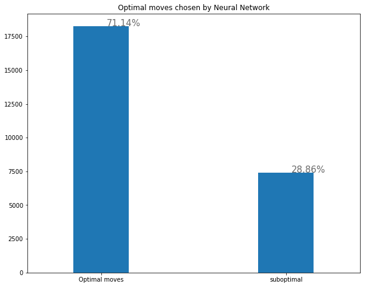

```python
optimal_moves_bar = pd.Series({'Optimal moves': optimal_moves,
               'suboptimal' : soptimal_moves})

plot = optimal_moves_bar.plot.bar(figsize=(10,8), width=0.3)

annotate_plot(plot)
plt.title("Optimal moves chosen by Neural Network")
plt.xticks(rotation=0)
plt.show()
```

```python
wins = matches_data[matches_data['win']==1]
wins = wins['win'].count()
wins
```

```
352
```

```python
lost = matches_data[matches_data['win']==0]
lost = lost['win'].count()
lost
```

```
548
```

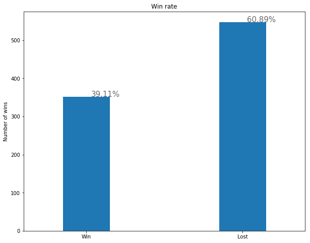

```python
win_rate = pd.Series({'Win': wins,
               'Lost' : lost})

plot = win_rate.plot.bar(figsize=(10,8), width=0.3)

annotate_plot(plot)
plt.title('Win rate')
plt.ylabel('Number of wins')
plt.xticks(rotation=0)
plt.show()
```

Average number of turns in each match

```python
matches_data['Number_turns'].mean()
```

```
83.18444444444444
```

# Analyze Opponent dataset

```python
opponent_data
```

|  | Opponent | Win_p1 | Lost_p1 | Draw_p1 | Win_p2 | Lost_p2 | Draw_p2 | Optimal_moves_nn | Sub_optimal_moves_nn |
| --- | --- | --- | --- | --- | --- | --- | --- | --- | --- |
| 0 | fop05 | 0 | 50 | 0 | 1 | 49 | 0 | 2272 | 944 |
| 1 | fop1 | 3 | 47 | 0 | 0 | 50 | 0 | 2530 | 997 |
| 2 | fop2 | 6 | 41 | 3 | 7 | 43 | 0 | 2994 | 1039 |
| 3 | fop3 | 7 | 42 | 1 | 11 | 36 | 3 | 3415 | 1195 |
| 4 | fop4 | 24 | 25 | 1 | 25 | 21 | 4 | 3825 | 1232 |
| 5 | fop5 | 28 | 19 | 3 | 39 | 10 | 1 | 4191 | 1545 |
| 6 | fop8 | 44 | 6 | 0 | 48 | 1 | 1 | 3634 | 1663 |
| 7 | oracle | 0 | 50 | 0 | 0 | 50 | 0 | 1882 | 883 |
| 8 | random | 50 | 0 | 0 | 50 | 0 | 0 | 1818 | 1277 |

Average number of match won by the neural network when plays as first player

```python
opponent_data['Win_p1'].mean()
```

```
18.0
```

Average number of match won by the neural network when plays as second player

```python
opponent_data['Win_p2'].mean()
```

```
20.11111111111111
```

Average number of match lost by the neural network when plays as first player

```python
opponent_data['Lost_p1'].mean()
```

```
31.11111111111111
```

Average number of match lost by the neural network when plays as second player

```python
opponent_data['Lost_p2'].mean()
```

```
28.88888888888889
```

Average number of match drawn by the neural network when plays as first player

```python
opponent_data['Draw_p1'].mean()
```

```
0.8888888888888888
```

```python
opponent_data['Draw_p2'].mean()
```

```
1.0
```